# VL03: Header-Dateien, Make, Virtueller Speicher

IFM 3.3 Systemprogrammierung, W19

Carsten Gips, FH Bielefeld

# Wiederholung

## Größe von Datentypen

```c
unsigned char a;
int b;

long long x[10];
long long y[] = {1, 2, 3};
long long z[7] = {3};
```

## Bit-Operatoren: Was kommt hier raus?

```c
x = 5;
x = x & 3;

x = 5;
x = x | 3;

x = 5;
x = x << 2;
```

Auflösung:

```
         16 8421
   5:  0000 0101
   3:  0000 0011

AND:   0000 0001: 1
OR:    0000 0111: 7
<< 2:  0001 0100: 20
```

## Warum ist der folgende Code-Schnipsel gefährlich?

```c
if (i=3)
    printf("Vorsicht");
else
    printf("Vorsicht (auch hier)");
```

## Prototypen und Strukturen

- Was sind Funktionsprototypen?
- Besonderheiten bei parameterlosen Funktionen?
- Erklären Sie folgenden C-Code:

  ```c
  struct a { int x; int y; } b;
  typedef struct c { int x; int y; } d;

  typedef unsigned long uint32;
  typedef struct a e;
  typedef struct c f;
  typedef d g;
  ```

## Variablen

- Wie erhält man in `main()` den Zugriff auf `x`?

  ```c
  int main() {
      /* Zugriff auf x?! */
      x = 42;
  }

  int x;
  void f() {
      int y;
      x=25; x++;
  }
  ```

- Erklären Sie den Unterschied zw. `x` und `y`.
- Wie ist die Lebensdauer von **lokalen statischen** Variablen?

# Motivation

## ???

```
CC      =  gcc
CFLAGS  =  -std=c11 -pedantic -Wall -Werror -I$(INCLUDE)
CFLAGS  += $(shell cmock-config --cflags)
INCLUDE =  ../include
OBJS    =  main.o fluppie.o

%.d: %.c
    $(CC) $(CFLAGS) -MM $^ > $@
-include $(OBJS:.o=.d)

.PHONY: all
all: fluppie

fluppie: $(OBJS)
    $(CC) -o $@ $^ $(LDFLAGS) $(LDLIBS)
```

## Themen für heute

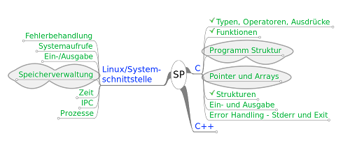

Am Ende der VL können/verstehen Sie:

- Deklarationen und Definitionen trennen
- Header-Dateien und bedingte Kompilierung einsetzen
- “Richtige” Makefiles schreiben
- Virtueller Speicher, Zusammenhang Pointer und Adressen

# Header-Dateien

## Bisher: Alles in einer Datei

```c
void fkt1();
void fkt2();

int main() {
    fkt1();
    fkt2();
}

void fkt1() {
    fkt2();
}

void fkt2() {
    ...
}
```

Beispiel: vl03/bedingte_uebersetzung/0_bisher/

Warum ist das keine gute Idee?

Ungünstig:

- Große, unübersichtliche Dateien
- Keine separate Schnittstellendefinition und Wiederverwendung möglich

## Versuch: Erste Aufteilung

```c
 /* ======== main.c ======== */
 #include "blatt.c"
 int main() {
     fkt1();
     fkt2();
 }
```

```c
 /* ======== blatt.c ======== */
 void fkt2() {
     ...
 }
 void fkt1() {
     fkt2();
 }
```

Beispiel: vl03/bedingte_uebersetzung/1_versuch/

=> Eclipse ist unglücklich darüber! Warum?

Wir haben bisher immer alles in “einem Rutsch” kompiliert, d.h. mit einem Aufruf aus allen Source-Dateien das Programm erzeugt. Hinter diesem einen Aufruf stehen in Wirklichkeit aber verschiedene Phasen der Übersetzung (siehe nächste Folie).

Eclipse betrachtet alle `.c`-Dateien in einem Projekt als echte Projektbestandteile und will diese einzeln kompilieren. Am Ende wird dann aus allen Objektdateien dann das ausführbare Programm zusammengebunden (gelinkt).

Die Datei `blatt.c` ist für sich kompilierbar, ebenso `main.c`. Wenn die daraus entstehenden Objektdateien zusammengelinkt werden, stellt der Compiler (genauer: der Linker) fest, dass die Funktionen `fkt1()` und `fkt2()` in beiden Objektdateien definiert sind (warum?). Das ist laut *One-Definition-Rule* nicht erlaubt und Eclipse zeigt eine Fehlermeldung an …

*Vorsicht*: Ohne Vorwärtsdeklaration ist unter Umständen die Reihenfolge der Implementierung wichtig!

## Überblick: Präprozessor, Compiler, Linker

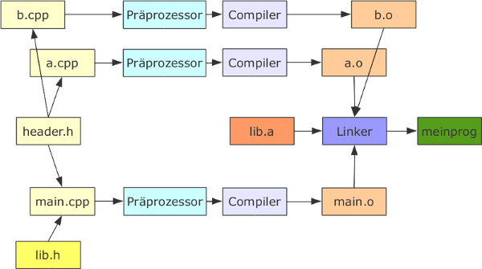

## One Definition Rule

> Jeder Name (Variable, Funktion, Struktur, Klasse, Konstante, …) hat genau eine Definition im gesamten Programm.

(Deklarationen kann es mehrere geben.)

*Hinweis*: Die “One Definition Rule” (*ODR*) ist in Wirklichkeit komplexer als hier dargestellt.

So dürfen beispielsweise Strukturen durchaus mehrfach im Programm (aber nicht mehrfach in einer Übersetzungseinheit, also beispielsweise einer zu kompilierenden Source-Datei) definiert werden, so lange sie exakt identisch sind. Es gibt noch weitere Ausnahmen, vgl. beispielsweise en.wikipedia.org/wiki/One_Definition_Rule (Punkt 3; dort für C++ dargestellt, wobei sich das auf C übertragen lässt).

Da es für Sie leichter merkbar und umsetzbar ist, habe ich die Regel wie oben dargestellt verkürzt.

## Quiz: Deklaration vs. Definition

- **Deklaration** führt (nur) einen Namen ein
- **Definition** Deklaration, die zusätzlich noch Speicherplatz anlegt oder innere Struktur eines/r Datentyps/Funktion beschreibt

```c
int a;
extern int a;

int f() { return 0; }
int f();

struct X {
    int a;
    struct X *x;
};
struct X x;
struct X;
```

## Versuch: Zweite Aufteilung

```c
 /* ======== main.c ======== */
 #include "blatt.h"
 int main() {
     fkt1();  fkt2();
 }
```

```c
 /* ======== blatt.c ======== */
 #include "blatt.h"
 void fkt1() { fkt2(); }
 void fkt2() { ... }
```

```c
 /* ======== blatt.h ======== */
 void fkt1();
 void fkt2();
```

Beispiel: vl03/bedingte_uebersetzung/2_versuch/

Für dieses *einfache* Beispiel würde das sogar klappen und ausreichend sein. Leider ist die Realität komplexer …

## Problem: Strukturen

```c
 /* ======== blatt.h ======== */
 void fkt1();
 void fkt2();

 struct studi {
     char *name;
     unsigned int credits;
 };

 int wuppie(struct studi);
```

Beispiel: vl03/bedingte_uebersetzung/3_strukturen/

Wenn Strukturen o.ä. in den Signaturen vorkommen, müssen diese **vollständig bekannt** sein. Eine einfache Deklaration (und spätere Definition in einer `.c`-Datei) der Strukturen reicht hier nicht!

**Problem**: Mehrfaches `#include` kann zu mehrfacher Definition in einem Kompilier-Vorgang führen!

## Präprozessor transformiert Quellcode *vor* dem Compiler-Lauf

=> Manipulation d. Programmcodes, *bevor* Compiler diesen “sieht”

1. *Einbinden von Header-Dateien* (und anderen Dateien)
2. **Bedingte Übersetzung**
3. Definition und Ersetzung von Makros (=> VL06)
- Präprozessor-Direktiven:
  - `#include`
  - `#define`
  - `#ifdef`, `#ifndef`, `#if`, `#else`, `#elif`, `#endif`

## Erinnerung Präprozessor: “include”

- Kopiert Text aus inkludierter Datei an die Stelle der `include`-Direktive
- Varianten:
  1. `#include <datei>`

     `datei` wird in Standardverzeichnissen gesucht (entsprechend Suchpfaden)
  2. `#include "datei"`

     `datei` wird lokal gesucht (im aktuellen Ordner)

Beispiel: vl03/defines.c

## Präprozessor: Bedingte Kompilierung

Ausweg: Bedingungen mit `#ifndef`, `#ifdef`, `#endif`

```c
/* ======== c.h ======== */
#ifndef C_H
#define C_H

struct X { int a, b; };

#endif   /* C_H */
```

Beispiel: vl03/bedingte_uebersetzung/4_bedingte-kompilierung/

In einem Kompilier-Vorgang:

- Erste Auswertung: Name `C_H` noch nicht definiert => Inhalt zw. `#ifndef` und `#endif` wird eingebunden
- Weitere Auswertungen: Name `C_H` bereits definiert => Inhalt zw. `#ifndef` und `#endif` wird ignoriert

*Anmerkung*: Dadurch ist die Definition der Struct pro Kompilier-Vorgang, d.h. pro Object-Datei (`*.o`), jeweils nur einmal vorhanden (Erfüllung der One-Definition-Rule). Beim Linken dieser Object-Dateien zu einem Programm wäre die One-Definition-Rule dann verletzt, aber hier greift eine der wenigen Ausnahmen (s.o.): So lange die mehrfachen Definitionen derselben Struct identisch sind, wird das beim Linken als eine einzige Definition betrachtet …

## Aufgabe: Teilen Sie das Programm auf! (10 Min.)

```c
/* Defines der Pins */
#define PIN_DATA  16    /* auf dem Shield PIN 15 */
#define PIN_CLOCK 27    /* auf dem Shield PIN 16 */
/* Datentypen mit enum und struct */
typedef ... led;
typedef ... brightness;
/* LED-Status (intern) */
brightness LED_Bar_Status[10];
/* interne Hilfsfunktionen */
void toggle_clock(void) { ... }
void send_led_data(void) { /* uses toggle_clock() */ }
/* Schnittstelle */
void init_led_bar(void) { /* uses LED_Bar_Status and send_led_data() */ }
int set_led(led l, brightness b) { /* uses LED_Bar_Status and send_led_data() */ }
/* Demo */
int main(void) {
    init_led_bar();  set_led(LED01, FULL);
}
```

Beispiel: vl03/bedingte_uebersetzung/aufgabe/

## Typische Aufteilung der Codebestandteile in C

1. Hauptprogramm `main()` => `main.c`
2. Headerdateien (`.h`): Schnittstellen
   - Funktionsprototypen, Klassendeklarationen
   - Deklarationen von Konstanten und globalen Daten
   - Definition von Datentypen (`struct`, `enum`)[^1]
3. Implementierungsdatei (`.c`): Definitionen
   - Funktionsdefinitionen (Implementierung)
   - Implementierung von Klassen
   - Definition globaler Objekte (Variablen, Konstanten, …), nur **einmal** im Programm

### Vorteile

- Besserer Überblick
- Getrennte Übersetzung (!)
- Weitergabe von kompiliertem Code (als Bibliothek) und Schnittstellen (Header-Dateien) => API

### Best-Practices bei Header-Dateien

1. Nutzen Sie für **alle** Header-Dateien **immer** eindeutige Include-Guards

   D.h. verwenden Sie immer folgendes Muster:

   ```c
   /* ======== XXX.h ======== */
   #ifndef XXX_H
   #define XXX_H

   // Header Declarations

   #endif   /* XXX_H */
   ```

2. Vermeiden Sie zyklische Abhängigkeiten zwischen Header-Dateien

   Das folgende Beispiel ist ein Anti-Pattern und würde wegen der zyklischen Abhängigkeit nicht kompilieren:

   ```c
   /* ======== a.h ======== */
   #ifndef a_H
   #define a_H

   #include "b.h"

   typedef struct a {
       B b;
   } A;

   #endif   /* a_H */


   /* ======== b.h ======== */
   #ifndef b_H
   #define b_H

   #include "a.h"

   typedef struct b {
       A a;
   } B;

   #endif   /* b_H */
   ```

   Abhilfe: Nach Möglichkeit dieses Pattern komplett vermeiden!

   (Falls dies nicht geht, sparsam mit Vorwärtsdeklarationen arbeiten. Im obigen Beispiel könnte man in `a.h` die Zeile `#include "b.h"` durch `struct b;` ersetzen (Vorwärtsdeklaration) und statt `B b;` entsprechend `struct b b;` schreiben.)
3. Keine Abhängigkeiten zu implizit importierten Namen

   Ein Header `a.h` könnte einen anderen Header `b.h` includen, welcher seinerseits einen Namen `wuppie` bereitstellt. Durch ein `#include <a.h>` könnten Sie also diesen Namen sofort verwenden.

   Ein Problem entsteht, wenn später das Include auf `a.h` entfernt wird, weil die von dort genutzten Namen nicht mehr gebraucht werden. Dann fehlt der Include auf `b.h`, und entsprechend würde der Gebrauch von `wuppie` vom Compiler mit einer Fehlermeldung quittiert.

   Guter Stil ist es deshalb, für den Namen `wuppie` explizit den deklarierenden Header `b.h` zu includen.
4. Header-Dateien sollten “self-contained” sein

   Wenn ein Header Symbole/Namen aus einem anderen Header verwendet, müssen diese per `#include` dieses anderen Headers explizit bekannt gemacht werden. Ansonsten würden die Header eine Reihenfolge beim Include erzwingen …

   Beispiel:

   ```c
   /* ======== a.h ======== */
   #ifndef a_H
   #define a_H

   typedef struct { int x; } A;

   #endif   /* a_H */


   /* ======== b.h ======== */
   #ifndef b_H
   #define b_H

   typedef struct { A a; } B;

   #endif   /* b_H */
   ```

   Wenn man in seinem Programm nun zuerst `#include "a.h"` und danach `#include "b.h"` schreibt, klappt alles. Wenn aber die Reihenfolge vertauscht wird, würde der Compiler sich beschweren, dass es kein `A` gibt …

   Abhilfe: In `b.h` die Zeile `#include "a.h"` ergänzen …
5. Kein `#include` mit lokalen Pfaden (s.u.)

   Statt lokalen Pfaden im `#include` besser mit Compiler-Schaltern (s.u.) arbeiten.

   Beispiel: Die Header eines Projekts liegen unter `/home/user/meinMurks/`. Man könnte also im Programm `#include "/home/user/meinMurks/foo.h"` schreiben. Damit zerstört man sich aber u.a. die Portierbarkeit! Allgemein üblich ist es, stattdessen `#include "foo.h"` zu schreiben und den Pfad dem Compiler per Schalter `-I/home/user/meinMurks/` zu setzen.

   Ausnahme: Häufig findet in C eine Art Namensraumbildung statt, indem man Header-Dateien einer gewissen Einheit in einem eigenen Unterordner bündelt. Beispielweise könnte man die Header zum Teil “LED-Anzeige” in einem eigenen Unterordner `/home/user/meinMurks/ledanzeige/` zusammenfassen, die Header für die “Studi-Verwaltung” dann unter `/home/user/meinMurks/studiverwaltung/`. Entsprechend würde der Include dann diese Ordner mit umfassen: `#include "ledanzeige/foo.h"` oder `#include "studiverwaltung/bar.h"` sowie der Compiler-Schalter `-I/home/user/meinMurks/`.
6. Vorgriff C++ (s.u.): C-Header müssen für die Verwendung in C++ entsprechend geschützt werden

   ```c
   #ifndef C_H
   #define C_H

   #ifdef __cplusplus
   extern "C" {
   #endif

   void fkt1();
   void fkt2();

   #ifdef __cplusplus
   }
   #endif

   #endif /* C_H */
   ```

7. Vorgriff C++ (Vl07): Keine anonymen Namespaces in Header-Dateien

   ```cpp
   namespace {
       int i;
   }
   void wuppie() {
       i++;
   }
   ```

   Das würde einen anonymen Namespace erzeugen, der Int-Variable `i` definiert. Der Zugriff auf diese Variable ist nur in der Übersetzungseinheit möglich, in der diese Definition steht. Dies entspricht dem `static` für globale Variablen in C …

   Wenn so eine Definition in einer Header-Datei erfolgen würde, würde durch den Präprozessor für jeden Include jeweils ein neuer anonymer Namespace mit einem neuen `i` definiert … Im Endergebnis wird dadurch nicht nur das erzeugte Programm u.U. deutlich größer, sondern es gibt schwer verständliche Fehler durch den Zugriff auf unterschiedliche Variablen (die vermeintlich nur einmalig existieren).

## Includes: Optionen für den GNU-Compiler

Schalter `-I<path>`: Pfad zu Include-Dateien (zusätzlich zu Standard-Pfad)

- Beispiel: Eigene Header-Dateien unter `/home/user/meinMurks/`
- Anti-Pattern:
  - `#include "/home/user/meinMurks/foo.h"`
  - `gcc -c main.c`
- Korrekt:
  - `#include "foo.h"`
  - `gcc -I/home/user/meinMurks/ -c main.c`

Wenn man eigene Header-Dateien implementiert, liegen diese i.d.R. nicht im Standard-Suchpfad, wo der GNU-Compiler nach Header-Dateien sucht. Man muss dem gcc/g++ über einen Schalter mitteilen, wo er nach den eigenen Headern suchen soll.

Die Option ist `-I` (“minus groß-Ieh”) gefolgt vom Pfad.

Wenn man im Projektordner also die Unterordner `src/` und `include/` hat, muss man beim Kompilieren im Projektordner die Option `-Iinclude` nutzen, beim Kompilieren im `src/`-Ordner dagegen `-I../include`.

Bei mehreren eigenen Include-Ordnern kann die Option `-I` auch mehrfach wiederholt werden.

*Hinweis*: Sie könnten alternativ den Pfad zu den Header-Dateien in den entsprechenden `#include "..."` hart codieren. Das ist **extrem schlechter Stil**! Zum einen ist das fehleranfällig, zum anderen sind diese Projekte nicht portabel und nicht wartbar, da der Code in exakt der hart codierten Ordnerstruktur kompiliert! **Inkludieren Sie also nur die eigentliche Header-Datei und nutzen Sie den Schalter `-I`!**

*Hinweis*: Häufig werden die Header-Dateien für ein (Teil-) Projekt in einem eigenen Unter-Ordner unterhalb von `include/` gruppiert. Beispielsweise würde man für ein Teilprojekt `ledanzeige` die zu diesem Teilprojekt gehörenden Headerdateien unter `include/ledanzeige/` sammeln. Zum Einbinden dieser Header würde man dann entsprechend `#include "ledanzeige/....h"` schreiben und beim Kompilieren den Schalter `-Iinclude` einsetzen.

## Globale Variablen: “extern”

- Globale Variablen gelten in allen Teilen des Programms
- Auch in anderen Dateien! => dort mit `extern` deklarieren

```c
/* ======== Datei main.c (einzeln kompilierbar) ======== */
int global;         // Definition

int main() {
    global = 123;
}
```

```c
/* ======== Datei a.c (einzeln kompilierbar) ======== */
extern int global;  // Deklaration

void fkt_a1() {
    global = 45;
}
```

Beide Dateien einzeln kompilierbar (`extern` sagt dem Compiler, dass die Variable woanders definiert ist) => erst der Linker löst das auf

## Sichtbarkeit globaler Variablen (und Funktionen): “static”

- Beschränkung der Gültigkeit von **globalen Variablen** auf die Datei, wo sie definiert sind: **Schlüsselwort `static`**
  - werden automatisch mit 0 initialisiert
  - sind nur in der Datei sichtbar/gültig, wo sie definiert sind
  - dient zur Vermeidung von Namenskonflikten bei globalen Variablen
- Sichtbarkeitsbeschränkung gilt auch für **Funktionen**

`static` für globale Variablen beschränkt deren Sichtbarkeit auf die Datei, wo sie definiert sind. D.h. man kann diese dann nicht in einer anderen Datei nutzen, nicht mal mit `extern` …

`static` für Funktionen beschränkt deren Sichtbarkeit ebenfalls auf die Datei, wo sie definiert sind. Man kann sie dann nur in anderen Funktionen, die ebenfalls in der selben Datei definiert werden, nutzen. In anderen Dateien sind die `static` Funktionen *nicht* sichtbar. D.h. es macht auch keinen Sinn, sie in einer Header-Datei zu deklarieren! (In der Praxis liefert der gcc dann sogar einen Fehler!). Das ist mit `private` Methoden vergleichbar.

### Hinweise

- Nicht verwechseln: globale `static` Variablen vs. lokale `static` Variablen!
- Vermeidung von Namenskonflikten besser mit Namespaces (C++)!
- Vermeiden Sie globale Variablen!
  - Fehler im Zusammenhang mit globalen Variablen sind extrem schwer zu finden!
  - “Zwang” zu globalen Variablen deutet auf schlechtes Software-Design hin!

## Globale Konstanten

### In C funktionieren globale Konstanten wie globale Variablen

- **Definition** in einer Übersetzungseinheit ohne “`extern`”

  => Definition als “`extern`” wird in C mit einer Warnung quittiert!
- Nutzung in anderen Übersetzungseinheiten durch (erneute) **Deklaration** als “`extern`”
- Beispiel:

  ```c
  /* ======== Datei main.c ======== */
  const int PI=123;       // Definition OHNE "extern" (C)

  int main() {
      fkt_a1();
      int x = PI;
      ...
  }
  ```

  ```c
  /* ======== Datei a.c ======== */
  extern const int PI;    // (erneute) Deklaration mit "extern"
  void fkt_a1() {
      int x = PI;
      ...
  }
  ```

### In C++ sind globale Konstanten per Default nur in ihrer Definitionsdatei sichtbar!

- Abhilfe: Definieren *und* Deklarieren mit `extern`
- Beispiel:

  ```cpp
  /* ======== Datei main.cpp ======== */
  extern const int PI=123;    // Definition MIT "extern" (C++)

  int main() {
      fkt_a1();
      int x = PI;
      ...
  }
  ```

  ```cpp
  /* ======== Datei a.cpp ======== */
  extern const int PI;        // (erneute) Deklaration mit "extern"
  void fkt_a1() {
      int x = PI;
      ...
  }
  ```

### Alternativ: In beiden Sprachen Konstanten vorwärts deklarieren

Folgende Definition und (Vorwärts-) Deklaration der Konstanten `PI` funktioniert sowohl in C als auch in C++:

```c
/* ======== Datei main.c ======== */
extern const int PI;    // (Vorwärts-) Deklaration mit "extern"
const int PI=123;       // Definition OHNE "extern"

int main() {
    fkt_a1();
    int x = PI;
    ...
}
```

```c
/* ======== Datei a.c ======== */
extern const int PI;    // (erneute) Deklaration mit "extern"
void fkt_a1() {
    int x = PI;
    ...
}
```

## Ausblick: C-Funktionsprototypen in C++ nutzen

In C++ werden Funktionsnamen im Vergleich zu C durch den Compiler etwas anders behandelt. Das kann u.U. Probleme in gemischtsprachigen Projekten (C und C++) bereiten, wenn C-Prototypen in C++-Programme eingebunden werden.

Um Schwierigkeiten zu vermeiden, kann man die C-Prototypen in der Headerdatei entsprechend markieren. Da das Makro `__cplusplus` nur bei der C++-Übersetzung aktiviert/gesetzt wird, hat die Ergänzung der Headerdateien keine Auswirkung auf das Übersetzen unter C. Bei Nutzung des C++-Compilers werden die C-Prototypen hingegen mit `extern "C" { ... }` eingebunden.

Vgl. Breymann (2011), Abschnitt 3.7.1

```c
 #ifndef C_H
 #define C_H

 #ifdef __cplusplus
 extern "C" {
 #endif

 void fkt1();
 void fkt2();

 #ifdef __cplusplus
 }
 #endif

 #endif /* C_H */
```

# Automatisierung mit Make

## Makefiles: Erinnerung

```
all: tollesProgramm

tollesProgramm: fkt.c fkt.h main.c
    gcc -o tollesProgramm -Wall -ansi -pedantic fkt.c main.c

clean:
    rm -rf tollesProgramm *.~
```

Unschön: Bei Änderungen wird immer **alles** kompiliert! => Zumindest nach Dateien trennen!

Konsole: vl03/make/, Makefile1 und Makefile2

## Makefiles und Variablen

- Variablen machen das Leben leichter:
  - Definition: `Variable = Wert` oder `Variable := Wert`
  - Benutzung: `$(Variable)` oder `${Variable}`

  Hinweis: Es gibt mehrere Formen der Zuweisung:
  - `VARIABLE = value`

    `value` wird evaluiert, wann immer `VARIABLE` ausgewertet/genutzt wird

    **Vorsicht mit zyklischen Auswertungen …**
  - `VARIABLE := value`

    `value` wird nur **einmal** bei der Zuweisung ausgewertet
  - Mit “`+=`” kann eine Variable erweitert werden, d.h.

    ```
    CFLAGS =  -c -g
    CFLAGS += -Wall
    CFLAGS += -ansi -pedantic
    ```

    ist äquivalent zu

    ```
    CFLAGS = -c -g -Wall -ansi -pedantic
    ```

- Eingebaute Variablen (kleine Auswahl):
  - `$<` => gibt die erste Abhängigkeit an
  - `$^` => gibt alle Abhängigkeiten an
  - `$@` => gibt das Ziel an

Konsole: vl03/make/Makefile3

## Makefile: Implizite Regeln

- Kompilieren von C-Programmen:

  Wann immer ein `n.o` gebraucht wird und ein `n.c` zur Verfügung steht, wendet GNU make die folgende Regel an:

  ```
  n.o: n.c
      $(CC) $(CFLAGS) -c $< -o $@
  ```

  Diese Regel brauchen Sie also nicht selbst definieren!
- Kompilieren von C++-Programmen:

  ```
  n.o: n.cpp
      $(CXX) $(CXXFLAGS) -c $< -o $@
  ```

  Dies entspricht der impliziten Regel für das Kompilieren von C-Programmen. Beachten Sie die geänderten Variablen! Als Endungen werden `.cc`, `.cpp` und `.C` akzeptiert.
- Linken: (Erstellen des Programms `n` aus `n.o`)

  ```
  n: n.o
      $(CC) $(LDFLAGS) $< $(LDLIBS) -o $@
  ```

  Wenn Ihre Regel wie die obige aussieht, brauchen Sie sie nicht selbst definieren!

  Falls `n` aus `n.o` und `b.o` sowie `c.o` erzeugt werden soll, muss man GNU make etwas nachhelfen und folgende Regel selbst definieren:

  ```
  n: n.o b.o c.o
  ```

  Falls der Name des zu generierenden Executables sich nicht aus einer der abhängigen Object-Dateien ableiten lässt, muss man leider eine komplette Regel für das Linken angeben:

### Eingebaute Variablen für implizite Regeln

- `CC`: C-Compiler, Default: `cc` (und damit auf den meisten Systemen `gcc`)
- `CXX`: C++-Compiler, Default: `g++`
- `CFLAGS`: Extra Flags für den C-Compiler (nur für Kompilieren) (Beispiel: `-g -Wall -ansi -pedantic`; **nicht** `-c` (das wird automatisch angefügt!))
- `CXXFLAGS` Extra Flags für den C++-Compiler (nur für Kompilieren)
- `LDFLAGS`: Extra Flags, die für das Linken genutzt werden (Beispiel: `-L.`; **nicht** `-lm`)
- `LDLIBS`: Bibliotheken, die für das Linken genutzt werden (Beispiel: `-lm -lfoo`; **nicht** `-L.`)

Vergleiche auch das Manual zu GNU make unter gnu.org/software/make/manual/make.html

Konsole: vl03/make/Makefile4

## Makefile: Substitutionen

- String-Matching:

  ```
  %.o: %.c
      $(CC) -c $(CFLAGS) $^ -o $@
  ```

  Das `%` ist ein Platzhalter: Wenn eine Datei `wuppie.o` gebraucht würde, würde der Dateiname auf `%.o` matchen, d.h. die Abhängigkeit in der Regel würde mit `wuppie.c` ersetzt:

  ```
  wuppie.o: wuppie.c
      $(CC) -c $(CFLAGS) $^ -o $@
  ```

  => Für eine `.o`-Datei braucht man die gleichnamige `.c`-Datei und muss dann die Regel anwenden.

  Mit `$*` könnte man bei Bedarf auf den gematchten String zurückgreifen, im Beispiel auf `wuppie`.
- Einschränkung auf Menge von Dateien:

  ```
  $(OBJ): %.o: %.c
      $(CC) -c $(CFLAGS) $^ -o $@
  ```

  Die Regel passt nur noch auf alle `.o`-Dateien, die in `$(OBJ)` definiert sind.
- Wildcard-Ersetzungen und Ersetzen von Endungen:

  ```
  SRC = $(wildcard *.c)
  OBJ = $(SRC:.c=.o)
  ```

  In `SRC` wären alle Dateien, die im aktuellen Ordner sind und auf `.c` enden. Für `OBJ` werden alle Elemente aus `SRC` genommen und die Endung `.c` durch `.o` ersetzt …
- Shell-Kommandos einsetzen:

  ```
  CMOCKFLAGS = $(shell cmock-config --cflags)
  ```

  Der Befehl `cmock-config --cflags` wird in einer Shell ausgeführt und das Ergebnis der Variablen `CMOCKFLAGS` als String zugewiesen.

## Makefile: Dateien vs. Namen: “.PHONY”

```
clean:
    rm -rf main $(OBJS) *.~
```

- `clean` ist kein Dateiname => GNU make sucht also umsonst nach einer Datei diesen Namens!
- Target ohne Abhängigkeit => Regel soll immer ausgeführt werden.

=> Falls Datei `clean` existieren würde, wäre Target immer aktuell! D.h. die Regel zum Löschen der temporären Dateien würde **nie** ausgeführt!

**Abhilfe**: Phony-Targets

```
.PHONY: clean
clean:
    rm -rf main $(OBJS) *.~
```

Empfehlung: Phony-Targets immer einsetzen, wenn das Target kein Dateiname ist

- Vermeidung der Probleme, falls es versehentlich doch die Datei mit dem Namen gibt …
- GNU make muss nicht erst nach der Datei suchen und prüfen, ob diese aktuell ist oder nicht, sondern kann direkt die Abhängigkeiten auswerten und die Regel ausführen!

## Makefile: Dependencies

```
fkt.o: fkt.c fkt.h
    gcc -c -Wall -ansi -pedantic fkt.c
```

ersetzt durch implizite Regel: `%.o: %c`

**Problem**: `.h`-Dateien sind keine Abhängigkeiten mehr!

=> Änderungen an den `.h`-Dateien werden nicht mehr erkannt bzw. führen nicht zur Neu-Kompilierung …

“`gcc -MM fkt.c`” => “`fkt.o: fkt.c fkt.h`”

Das ist eine Regel für GNU Make, die sich mit anderen Regeln für `fkt.o` ergänzt! (Stichwort: “Multiple Rules for One Target”)

- Generieren dieser Abhängigkeits-Regeln für alle Quellcode-Dateien und Speichern in `.d`-Dateien
- Laden der Regeln in den `.d`-Dateien mit `include`

Sobald sich eine Abhängigkeit ändert, also auch ein ggf. eingebundenes `.h`-File, würde das entsprechende Object-File neu kompiliert.

*Anmerkung*: Normalerweise bricht GNU make ab, wenn bei der Ausführung einer Regel ein Fehler auftritt. Mit einem “`-`” vor der Regel wird der Fehler zwar ausgegeben, aber die Ausführung fortgesetzt.

Dies nutzen wir beispielsweise bei den Makefiles für die Testfälle, da Valgrind auf der Raspberry-Plattform einen Fehler hat, wodurch die Ausführung der Tests normalerweise komplett abgebrochen werden würde.

Beispiel:

```
-include $(SRC:.c=.d)

abgabe: $(TESTS)
    -valgrind --leak-check=yes ./studiverwaltung
```

Konsole: vl03/make/Makefile5

## Aufgabe: Schreiben Sie ein Makefile! (10 Min.)

```c
/* ======== ledbar_intern.h ======== */
#define PIN_DATA  16    /* auf dem Shield PIN 15 */
#define PIN_CLOCK 27    /* auf dem Shield PIN 16 */

/* ======== ledbar.h ======== */
typedef ... led;
typedef ... brightness;

/* ======== ledbar.c ======== */
brightness LED_Bar_Status[10];
void toggle_clock(void) { ... }
void send_led_data(void) { /* uses toggle_clock() */ }
void init_led_bar(void) { /* uses LED_Bar_Status and send_led_data() */ }
int set_led(led l, brightness b) { /* uses LED_Bar_Status and send_led_data() */ }

/* ======== main.c ======== */
int main(void) {
    init_led_bar();  set_led(LED01, FULL);
}
```

Beispiel: vl03/bedingte_uebersetzung/aufgabe/

## Makefile: Standard-Targets

Unix-Dreisprung: **`./configure && make && make install`**

- **`all`**: Kompilieren => Kompiliert alle geforderten Programme und Bibliotheken im `src/`-Unterordner
- **`install`**: Kopieren => Kopiert die durch `all` erzeugten Programme nach `bin/` und die Bibliotheken nach `lib/`
- **`test`**: Testen => Ruft das `test`-Target im `tests/`-Makefile auf
- **`run`**: Ausführen => Lässt die in `bin/` installierten Programme laufen
- **`doc`**: Generierung der Doku => Generiert mit Doxygen die Dokumentation zu Ihrem Programm in den Unterordner `doc/`
- **`clean`**: Aufräumen => Entfernt alle temporären (generierten) Dateien in `src/`
- **`distclean`**: Gründliches Aufräumen => Wie `clean`, entfernt zusätzlich die `bin/`-, `lib/`- und `doc/`-Unterordner

**Konvention**: **`all`** ist das erste Target

Vgl. Regeln zur Bearbeitung der Praktikumsaufgaben im ILIAS

## Ausblick: Rekursiver Make-Aufruf

```
 ## Makefile auf Projektebene
 export CC = gcc
 all:
    cd src/ && $(MAKE) prog
 clean:
    $(MAKE) -C src/ clean
```

```
 ## Makefile im Unterverzeichnis src/
 prog: $(patsubst %.c, %.o, $(wildcard *.c))
    $(CC) -o $@ $^
 clean:
    rm -rf *.o prog *.~
```

Mit Hilfe von `export` können Sie Variablen “exportieren”, d.h. Sie können auf diese Variablen in den Untermakefiles zugreifen.

Die Aufrufe `cd XXX/ && $(MAKE) YYY` und `$(MAKE) -C XXX/ YYY` sind in der Wirkung identisch: Gehe in den Ordner `XXX` und rufe dort Make mit dem Target `YYY` auf.

## Ausblick: GNU Autotools und CMake

- Makefiles für große Projekte sehr komplex
- Makefiles sollen auf vielen Systemen funktionieren
- GNU Autotools: [Autoconf](https://www.gnu.org/software/autoconf/autoconf.html) und [Automake](https://www.gnu.org/software/automake/)
  - User: `./configure && make && make install` (“Unix-Dreisprung”)
  - Programmierer:
    - Bereitstellung von Konfigurationsdateien: `configure.ac`, `Makefile.am` in jedem Verzeichnis
    - Aufruf `autoreconf` und `automake -a` in jedem Verzeichnis
- Alternative: [**CMake**](https://cmake.org/)
  - Deutlich einfachere Konfigurationsdateien
  - Nachteil: Installation von CMake nötig für Konfigurationsänderungen

# Speicherverwaltung

## Speicherverwaltung

[figure not shown]

Quelle: [afrank99 (CC BY-SA 2.0, de.wikipedia.org)](https://commons.wikimedia.org/wiki/File:SODIMM_64MB_SDRAM.JPG)

[figure not shown]

Quelle: [Rochellesinger (CC BY-SA 2.5, de.wikipedia.org)](https://commons.wikimedia.org/wiki/File:Disassembled_HDD_and_SSD.JPG)

- Diverse Arten von physikalischem Speicher: Cache, RAM, SSD, Festplatte
  - unterschiedlich groß
  - unterschiedlich schnell
  - unterschiedlich teuer
- Prozesse laufen (quasi-) parallel: Umgang mit Speicher?
  - Prozesse benötigen u.U. mehr Speicher als RAM vorhanden
  - Prozesse sollen sich nicht um die Verwaltung des physikalischen Speichers kümmern müssen (und sollen nicht direkt zugreifen)
  - Prozesse sollen (normalerweise) nicht auf Speicherbereiche anderer Prozesse zugreifen (Sicherheit!)
  - Wo sinnvoll, sollen sich Prozesse gemeinsame Speicherbereiche teilen
- **Lösung**: Virtueller Speicher

## Virtueller Speicher

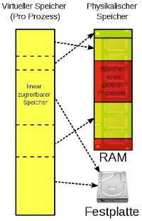

Quelle: [Ehamberg and Shaddim (CC BY-SA 3.0, de.wikipedia.org)](https://commons.wikimedia.org/wiki/File:Virtual-memory-german.svg)

- Kernel weist jedem Prozess seinen eigenen virtuellen Speicher zu
  - Linearer Adressbereich, beginnend mit Adresse 0 bis zu einer maximalen Adresse
- Verwaltung durch MMU (*Memory Management Unit*)
  - MMU bildet logische Adressen aus virtuellem Speicher auf den physikalischen Speicher ab
  - Transparent für den Prozess

## Segmente des virtuellen Speichers: Text

- **Text Segment** (read-only)
  - Programm Code
  - Konstanten, String Literale
- Bereich initialisierter Daten
  - globale und static Variablen (explizit initialisiert)
- Bereich uninitialisierter Daten
  - globale und static Variablen (uninitialisiert) => Wert 0

**ACHTUNG**: Bereich (un-) initialisierter Daten nicht in Abbildung dargestellt!

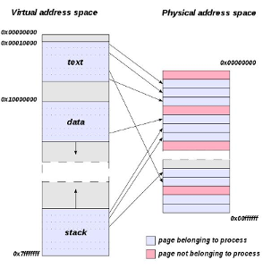

Quelle: [Dysprosia and Stannered (BSD, de.wikipedia.org)](https://commons.wikimedia.org/wiki/File:Virtual_address_space_and_physical_address_space_relationship.svg)

## Segmente des virtuellen Speichers: Stack

- Stackframe je Funktionsaufruf:
  - Lokale Variablen (“automatische” Variablen)
  - Argumente und Return-Werte
- Dynamisch wachsend und schrumpfend
- Automatische Pflege
  - Nach Funktionsrückkehr wird der Stackpointer (“Top of Stack”) weiter gesetzt
  - Dadurch “Bereinigung”: Speicher der lokalen Variablen wird freigegeben

## Segmente des virtuellen Speichers: Data (Heap)

- Bereich für dynamischen Speicher (Allokation während der Laufzeit)
- Dynamisch wachsend und schrumpfend
- Zugriff und Verwaltung aus laufendem Programm => Pointer
  - `malloc()`/`calloc()`/`free()` (C)
  - `new`/`delete` (C++)
  - typischerweise **Pointer**

## Pointer sind Variablen

**Pointer sind Variablen**:

- haben Namen und Wert
- können mit Operatoren verändert werden
- sind einer Speicheradresse im virtuellen Speicher zugeordnet

## Pointer sind besondere Variablen

Wert des Pointers wird als **Adresse** im Speicher behandelt

Wirkung/Interpretation: Variable `iptr` “zeigt” auf die Adresse von Variable `i`

## Pointer und Adressen (Syntax)

- Deklaration

  ```c
  Typ * Name;
  ```

- Zuweisung einer Adresse über den `&`-Operator:

  ```c
  int i = 99;
  int *iptr;

  iptr = &i;  /* Wert von iptr ist gleich Adresse von i */
  ```

- `iptr` ist ein Pointer auf eine (beliebige) Speicherzelle mit Inhalt vom Typ `int`
- Nach Zuweisung: `iptr` ist ein Pointer auf die Speicherzelle der Variablen `i`

## Pointer und Adressen (Interpretation)

```c
int i = 99;
int *iptr;

iptr = &i;  /* Wert von iptr ist gleich Adresse von i */
```

## Anwendung: Einlesen von Tastatureingaben

```c
#include <stdio.h>    // int scanf(const char *format, ...);

int x, alter;
x = scanf("%d", &alter);
```

- Einlesen mit `scanf()`
  - Parameter: Formatstring und weitere Parameter
  - Rückgabewert: Anzahl der gelesenen Werte
  - Formatstring: Formatanweisungen, Leerzeichen und andere Zeichen (wie `printf()`)
    - Zeichen hinter Prozentzeichen beschreiben erwarteten Datentyp
    - Leerzeichen passen zu Leerraum jeder Größe
    - Andere Zeichen passen nur zu sich selbst
  - Eingaben werden an die als Argument übergebenen Adressen geschrieben.
- C: Call-by-Value! Wie kann `scanf()` in die Variable `alter` schreiben?

  => Übergebe die **Adresse** von `alter`, d.h. einen Pointer auf `alter`!

## Ein- und Ausgabe auf der Konsole

Es existieren drei Standard-Ein-/Ausgabekanäle, per Default mit Konsole verknüpft:

- `stdin`: Einlesen von Tastatureingaben
- `stdout`: normale Ausgabe auf der Konsole
- `stderr`: Fehlerausgabe auf der Konsole
- Nutzung:
  - Einbinden von `stdio.h`
  - Ausgabe auf Konsole mit Funktion `printf()`
  - Einlesen von Zeichen mit `scanf()`

*Hinweis*: Varianten mit vorangestelltem “f” mit Angabe des Kanals

Beispiel: `fprintf(stderr, "formatstring", arg1, arg2, ...)`

Beispiel: vl03/scanf.c

# Zusammenfassung

## tl;dr

- Unterschied Deklaration und Definition, *One Definition Rule*
- Header-Dateien und bedingte Kompilierung
- Bedeutung von `extern` und `static`
- Elemente “echter” Make-Files
  - Definition von Variablen
  - Phony-Targets
  - Ersetzungen
  - Implizite Variablen und Regeln
  - Abhängigkeiten beachten
- Virtueller Speicher: Kernel stellt Prozessen linearen Adressraum bereit

  Segmente: Text, Stack, Heap
- Pointer sind Variablen, deren **Wert als Adresse** interpretiert wird
- Pointer können auf andere Objekte/Variablen zeigen:
  - Adressoperator “`&`” liefert Adresse eines Objekts, Zuweisung an Pointer
  - Pointer können mit “`*`” dereferenziert werden: Zugriff auf verwiesenes Objekt

**Nächste Woche**: Pointer und Dynamische Speicherverwaltung

## Literatur zum Weiterlesen

- Breymann (2011)
  - Präprozessor, Sichtbarkeit: Abschnitt 3.3
  - Make: Kapitel 17 (und Kapitel 23)
- Goll und Dausmann (2014)
  - Präprozessor: Kapitel 21
  - Header, modulares Design: Kapitel 22
- man-Page: `man 1 make`
- [GNU make: gnu.org/software/make/manual/make.html](https://www.gnu.org/software/make/manual/make.html)
- Wolf (2006)
  - Make: Kapitel 17.1
- Wolf (2009)
  - `scanf()`: Kapitel 4
- Für Interessierte zum Thema *Virtueller Speicher*: Love (2013) und Kerrisk (2010)

### Bibliographie

Breymann, U. 2011. *Der C++ Programmierer*. 2. Auflage. Hanser. ISBN: 978-3-446-42691-7.

Goll, J.; und M. Dausmann. 2014. *C als erste Programmiersprache*. 8. Aufl. Springer Fachmedien Wiesbaden. DOI: 10.1007/978-3-8348-2271-0.

Kerrisk, M. 2010. *The Linux Programming Interface*. No Starch Press. ISBN: 978-1-5932-7220-3.

Love, R. 2013. *Linux System Programming: Talking Directly to the Kernel and C Library*. O’Reilly. ISBN: 978-1-4493-3953-1.

Wolf, J. 2006. *Linux-UNIX-Programmierung*. 2. Auflage. Rheinwerk Computing. ISBN: 3-89842-749-8. URL: http://openbook.rheinwerk-verlag.de/linux_unix_programmierung/ (zugegriffen 03.08.2018).

———. 2009. *C von A bis Z*. 3. Auflage. Rheinwerk Computing. ISBN: 978-3-8362-1411-7. URL: http://openbook.rheinwerk-verlag.de/c_von_a_bis_z/ (zugegriffen 03.08.2018).

## Lernziele – Nach dieser Vorlesung sollten Sie …

### Kennen (K1)

- Virtueller Speicher, Segmente: Text, Data, Stack

### Verstehen (K2)

- One Definition Rule
- Unterschied Deklaration vs. Definition
- Dateiübergreifende Sichtbarkeit: lokale vs. globale Variablen/Konstanten
- Aufbau von Makefiles (Variablen, Regeln), Erzeugen von Targets
- Pointer sind Variablen, Wert wird als Adresse interpretiert

### Anwenden (K3)

- Aufteilen in `.h` und `.c` Dateien
- Beachten der *One Definition Rule* durch bedingte Übersetzung
- Automatisiertes Übersetzen mit Hilfe von Make
- Einfache Ein- und Ausgabe mit `scanf()` und `printf()` unter Nutzung von Pointern

## Diese Fragen sollten Sie beantworten können …

### Aufbau von Header-Dateien

Erklären Sie die folgenden Konstrukte in einer fiktiven Header-Datei. Wozu werden sie benötigt?

```c
 // c.h
 #ifndef C_H
 #define C_H

 struct X {
     int a, b;
 };

 #endif // C_H
```

### Aufbau von Makefiles

Erklären Sie den Aufbau des folgenden fiktiven Makefiles. Was würde beim Aufruf von `make` und `make fkt.o` passieren?

```
all: tollesProgramm

tollesProgramm: fkt.o main.o
    gcc -o $@ $^

main.o: main.c fkt.h
    gcc -c $<

%.o: %.c
    gcc -c $<

clean:
    rm -rf main.o fkt.o *.~
```

Was würde geschehen, wenn man die vorletzte Regel (`%.o: %.c`) weglassen würde?

### Unterschiedliche Variablenarten

Welche der folgenden Aussagen sind wahr?

- nicht-globale, nicht-static Variablen:
  - werden bei Betreten des Blockes angelegt
  - und beim Verlassen automatisch zerstört (Stack!)
  - werden automatisch mit 0 initialisiert
  - bleiben bis zum Programmende erhalten, d.h. der alte Wert ist beim nächsten Betreten des Blockes noch da
- static bei lokalen Variablen:
  - sind nur in ihrem Block gültig
  - werden automatisch mit 0 initialisiert
  - bleiben bis zum Programmende erhalten, d.h. der alte Wert ist beim nächsten Betreten des Blockes noch da
  - können in anderen Programmteilen über das Schlüsselwort `extern` bekannt gemacht werden und dort genutzt werden
- globale, nicht-static Variablen:
  - können direkt in allen Programmteilen benutzt werden
  - bleiben bis zum Programmende erhalten
- static bei globalen Variablen:
  - können in anderen Programmteilen über das Schlüsselwort `extern` bekannt gemacht werden und dort genutzt werden
  - bleiben bis zum Programmende erhalten
- globale Konstanten:
  - können in anderen Programmteilen über das Schlüsselwort `extern` bekannt gemacht werden und dort genutzt werden
  - müssen mit dem Schlüsselwort `extern` definiert werden

### Deklaration vs. Definition

Unterscheiden Sie Deklaration und Definition:

```c
int x;
extern const float y = 3.141;
int d() {}
extern int x;
struct X {
    int a, b;
}
extern const float PI;
enum Z {c, d};
Z x;
struct X;
X y;
int d();
enum Z;
```

### Pointer

- Was ist der Unterschied zwischen einem Pointer und einer “normalen” Variablen?
- Wie erhält man die Adresse einer Variablen?
- Können mehrere Pointer auf einen Speicherbereich (Variable, Struktur) zeigen?
- Was bedeutet `int i=0, *ip=&i;`?
- Wie können Sie feststellen, ob Sie mit `scanf()` wirklich die gewünschten Werte gelesen haben?

## Selbststudium

### Speicherlayout, Tücken in C/C++

Wie lange läuft folgender Code? Und warum?!

```c
int main() {
    int i, x[8];
    for (i=0; i<=sizeof(x); i++) {
        x[i]=0;
    }
}
```

*Hinweis:* Nutzen Sie den Debugger :-)

[^1]: in .c-Dateien muss Größe der Typen bekannt sein